# Markdown Files — My sample book

[figure not shown]

# Tugas 2 : Prediksi Jumlah Produksi Kopi pada Negara Brazil.

# Data Understanding

Dataset produksi kopi ini menyajikan informasi historis tentang produksi kopi di berbagai negara selama periode waktu tertentu, dimulai dari musim panen 1990/91 hingga 2019/20. Data ini terdiri dari variabel-variabel kunci, seperti negara penghasil kopi, jenis kopi yang diproduksi, serta jumlah produksi tahunan.

Dataset yang digunakan dalam pengerjaan kali ini didapat dari kaggle https://www.kaggle.com/datasets/michals22/coffee-dataset lebih tepatnya pada bagian datasets produksi kopi.

Pada tugas kali ini penulis menggunakan prediksi produksi kopi lebih mengerucutkan untuk memprediksi jenis kopi apa yang banyak di produksi pada negara Brazil.

- Country (Negara) : fitur ini berisi nama negara yang memproduksi kopi. Dengan type data kategori (Categorical)
- Coffee Type (Jenis Kopi) : fitur ini berisi jenis kopi yang diproduksi oleh negara tersebut. Kopi ini diklasifikasikan menjadi 2 jenis kopi yaitu Arabika dan Robusta. Dengan type data kategori (Categorical)
- 1990/91, 1991/92, 1992/93, dst. (keterangan produksi kopi tahunan) : fitur ini berisi mengenai jumlah produksi kopi id negara tersebut pada periode panen tertentu
- Total Production (Total Produksi) : fitur ini menunjukkan total produksi kopi dari suatu negara selama periode tertentu. Nilai ini menujukkan jumlah dari seluruh produksi tahunan dari setiap negara.
- Data Understanding

Pada dataset ini kita memiliki banyak data dari berbagai negara yang memproduksi berbagai macam jenis kopi. Pada tugas kali ini berfokus pada negara Brazil yang jenis kopinya adalah Arabica/Robusta. kali ini tugas ini akan memprediksi jumlah kopi yang akan di produksi pada tahun berikutnya.

# Menampilkan Data

Berikut merupakan tampilan data pada dataset produksi kopi yang mengkerucut pada negara satu negara yaitu negara Brazil.

```python
import pandas as pd
    url = 'https://raw.githubusercontent.com/Auliyaaas/Proyek-Sains-Data/main/PSD/CoffeeProduction/Coffee_production.csv'
    df = pd.read_csv(url)
```

```python
df.info()
```

```
<class 'pandas.core.frame.DataFrame'>
    RangeIndex: 55 entries, 0 to 54
    Data columns (total 33 columns):
     #   Column            Non-Null Count  Dtype
    ---  ------            --------------  -----
     0   Country           55 non-null     object
     1   Coffee type       55 non-null     object
     2   1990/91           55 non-null     float64
     3   1991/92           55 non-null     float64
     4   1992/93           55 non-null     float64
     5   1993/94           55 non-null     float64
     6   1994/95           55 non-null     float64
     7   1995/96           55 non-null     float64
     8   1996/97           55 non-null     float64
     9   1997/98           55 non-null     float64
```

[output cut: 25 more lines]

```python
import pandas as pd

    # Pastikan untuk mengganti 'coffee_dataset.csv' dengan nama file dataset Anda
    file_path = 'https://raw.githubusercontent.com/Auliyaaas/Proyek-Sains-Data/main/PSD/CoffeeProduction/Coffee_production.csv'

    # Membaca dataset
    data = pd.read_csv(file_path)

    # Menampilkan kolom untuk memastikan kolom negara (misalnya 'Country') tersedia
    print(data.columns)

    # Menyaring data untuk Brazil dan menghitung jumlah baris
    brazil_data = data[data['Country'] == 'Brazil']
    print(f"Jumlah data produksi kopi di Brazil: {len(brazil_data)}")
```

```
Index(['Country', 'Coffee type', '1990/91', '1991/92', '1992/93', '1993/94',
           '1994/95', '1995/96', '1996/97', '1997/98', '1998/99', '1999/00',
           '2000/01', '2001/02', '2002/03', '2003/04', '2004/05', '2005/06',
           '2006/07', '2007/08', '2008/09', '2009/10', '2010/11', '2011/12',
           '2012/13', '2013/14', '2014/15', '2015/16', '2016/17', '2017/18',
           '2018/19', '2019/20', 'Total_production'],
          dtype='object')
    Jumlah data produksi kopi di Brazil: 1
```

```python
print(brazil_data.columns)
```

```
Index(['Country', 'Coffee type', '1990/91', '1991/92', '1992/93', '1993/94',
           '1994/95', '1995/96', '1996/97', '1997/98', '1998/99', '1999/00',
           '2000/01', '2001/02', '2002/03', '2003/04', '2004/05', '2005/06',
           '2006/07', '2007/08', '2008/09', '2009/10', '2010/11', '2011/12',
           '2012/13', '2013/14', '2014/15', '2015/16', '2016/17', '2017/18',
           '2018/19', '2019/20', 'Total_production'],
          dtype='object')
```

Berikut merupakan bentuk grafik produksi kopi dari dataset yang ada dari rentan waktu 30 tahun terhitung dari tahun 1990 hingga 2020.

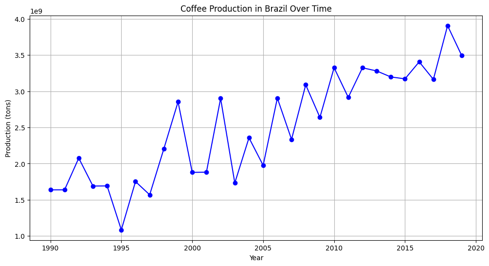

```python
import pandas as pd
    import matplotlib.pyplot as plt

    # Load dataset
    file_path = 'https://raw.githubusercontent.com/Auliyaaas/Proyek-Sains-Data/main/PSD/CoffeeProduction/Coffee_production.csv'  # Ganti dengan path ke file Anda
    data = pd.read_csv(file_path)

    # Pilih hanya kolom tahun (yang memiliki '/') dan identifikasi kolom lainnya
    year_columns = [col for col in data.columns if '/' in col]
    id_vars = ['Country', 'Coffee type']

    # Transformasi data: kolom tahun menjadi baris
    melted_data = data.melt(id_vars=id_vars,
                            value_vars=year_columns,
                            var_name='Year',
                            value_name='Production')

    # Bersihkan kolom 'Year' agar hanya berisi tahun awal
    melted_data['Year'] = melted_data['Year'].str[:4].astype(int)

    # Filter untuk negara tertentu (misalnya 'Brazil') jika diinginkan
    country_data = melted_data[melted_data['Country'] == 'Brazil']

    # Plot data produksi untuk Brazil
    plt.figure(figsize=(12, 6))
    plt.plot(country_data['Year'], country_data['Production'], marker='o', linestyle='-', color='b')
    plt.title('Coffee Production in Brazil Over Time')
    plt.xlabel('Year')
    plt.ylabel('Production (tons)')
    plt.grid()
    plt.show()
```

- Menghitung jumlah kopi yang diproduksi selama rentan waktu 1990/91 hingga 2019/20

```python
import pandas as pd

    # Membaca dataset
    file_path = 'https://raw.githubusercontent.com/Auliyaaas/Proyek-Sains-Data/main/PSD/CoffeeProduction/Coffee_production.csv'  # Ganti dengan path file yang sesuai
    data = pd.read_csv(file_path)

    # Filter data untuk Brasil saja
    brazil_data = data[data['Country'] == 'Brazil']

    # Daftar kolom tahun yang akan dijumlahkan (1990/91 hingga 2021/22)
    year_columns = [col for col in brazil_data.columns if col >= '1990/91' and col <= '2021/22']

    # Menghitung total produksi kopi khusus untuk Brasil dari 1990/91 hingga 2021/22
    total_production_brazil = brazil_data[year_columns].sum().sum()

    # Menampilkan data Brasil dan total produksi
    print(brazil_data)
    print(f'\nTotal produksi kopi di Brasil dari 1990/91 hingga 2021/22: {total_production_brazil}')
```

```
  Country      Coffee type       1990/91       1991/92       1992/93  \
    2  Brazil  Arabica/Robusta  1.637160e+09  1.637580e+09  2.076180e+09

            1993/94       1994/95       1995/96       1996/97       1997/98  ...  \
    2  1.690020e+09  1.691520e+09  1.083600e+09  1.751820e+09  1.568880e+09  ...

            2011/12       2012/13       2013/14       2014/15       2015/16  \
    2  2.915520e+09  3.325080e+09  3.281340e+09  3.198300e+09  3.172260e+09

            2016/17       2017/18       2018/19       2019/20  Total_production
    2  3.407280e+09  3.164400e+09  3.907860e+09  3.492660e+09      7.508298e+10

    [1 rows x 33 columns]

    Total produksi kopi di Brasil dari 1990/91 hingga 2021/22: 75082980000.0
```

Code diatas menunjukkan ada berapa semua jumlah produksi yang dihasilkan dari rentan waktu 1990/91 hingga 2021/22. Dan diperoleh jumlah produksi kopi yang dihasilkan adalah **75082980000.0** terhitung jika dibaca adalah 75,082,980,000 kg

```python
import pandas as pd

    # Membaca dataset
    file_path = 'https://raw.githubusercontent.com/Auliyaaas/Proyek-Sains-Data/main/PSD/CoffeeProduction/Coffee_production.csv'  # Ganti dengan path file yang sesuai
    data = pd.read_csv(file_path)

    # Menampilkan beberapa baris pertama dari dataset untuk memahami strukturnya
    print(data.head())

    # Filter data untuk Brasil
    brazil_data = data[data['Country'] == 'Brazil']

    # Menghitung jumlah jenis kopi berdasarkan tahun
    # Misalkan kolom 'Coffee_Type' menunjukkan jenis kopi
    coffee_types_count = brazil_data['Coffee type'].nunique()

    print(f'Jumlah jenis kopi yang diproduksi di Brasil: {coffee_types_count}')
```

```
                            Country      Coffee type       1990/91  \
    0                            Angola  Robusta/Arabica  3.000000e+06
    1  Bolivia (Plurinational State of)          Arabica  7.380000e+06
    2                            Brazil  Arabica/Robusta  1.637160e+09
    3                           Burundi  Arabica/Robusta  2.922000e+07
    4                           Ecuador  Arabica/Robusta  9.024000e+07

            1991/92       1992/93       1993/94       1994/95       1995/96  \
    0  4.740000e+06  4.680000e+06  1.980000e+06  4.620000e+06  3.720000e+06
    1  6.240000e+06  7.200000e+06  3.060000e+06  7.020000e+06  8.520000e+06
    2  1.637580e+09  2.076180e+09  1.690020e+09  1.691520e+09  1.083600e+09
    3  4.002000e+07  3.720000e+07  2.358000e+07  3.984000e+07  2.604000e+07
    4  1.274400e+08  7.110000e+07  1.241400e+08  1.425600e+08  1.132800e+08

            1996/97       1997/98  ...       2011/12       2012/13       2013/14  \
```

[output cut: 22 more lines]

Code diatas merupakan code untuk mengetahui jumlah jenis kopi yang dihasilkan dari rentan waktu 30 tahun sejak 1990/91 hingga 2019/20 pada negara Brazil, dan di peroleh hanya ada 1 jenis kopi di negara brazil ini.

## Missing Value

Missing Values adalah hilangnya beberapa data yang telah diperoleh. Menangani MissingValues dengan tepat sangat penting untuk memastikan integritas dan akurasi analisis data.

```python
import pandas as pd

    # Membaca dataset
    url = 'https://raw.githubusercontent.com/Auliyaaas/Proyek-Sains-Data/main/PSD/CoffeeProduction/Coffee_production.csv'
    df = pd.read_csv(url)

    # Memfilter data untuk negara Brazil
    brazil_data = df[df['Country'] == 'Brazil']

    # Memeriksa missing value pada dataset Brazil
    missing_values = brazil_data.isnull().sum()

    # Menampilkan kolom dengan jumlah missing value
    print("Missing values pada data Brazil:")
    print(missing_values[missing_values > 0])

    # Jika ingin menampilkan data dengan missing value
    data_with_missing = brazil_data[brazil_data.isnull().any(axis=1)]
    print("\nData dengan missing values:")
    print(data_with_missing)
```

```
Missing values pada data Brazil:
    Series([], dtype: int64)

    Data dengan missing values:
    Empty DataFrame
    Columns: [Country, Coffee type, 1990/91, 1991/92, 1992/93, 1993/94, 1994/95, 1995/96, 1996/97, 1997/98, 1998/99, 1999/00, 2000/01, 2001/02, 2002/03, 2003/04, 2004/05, 2005/06, 2006/07, 2007/08, 2008/09, 2009/10, 2010/11, 2011/12, 2012/13, 2013/14, 2014/15, 2015/16, 2016/17, 2017/18, 2018/19, 201…
    Index: []

    [0 rows x 33 columns]
```

KESIMPULAN : dapat dilihat bahwa tidak terdapat missing values dalam dataset sehingga tidak dibutuhkan proses lebih lanjut untuk penanganan missing value

## Outlier pada dataset Coffee_production.csv

Outlier adalah data yang berbeda secara signifikan dari data lain dalam sebuah set data. Mereka bisa menjadi nilai yang sangat kecil atau sangat besar dibandingkan dengan nilai rata-rata atau mayoritas data lainnya. Pada code ini akan menampilkan outlier terkhusus pada negara brazil karen pada proyek ini terkhusus untuk negara Brazil.

```
Index(['Country', 'Coffee type', '1990/91', '1991/92', '1992/93', '1993/94',
           '1994/95', '1995/96', '1996/97', '1997/98', '1998/99', '1999/00',
           '2000/01', '2001/02', '2002/03', '2003/04', '2004/05', '2005/06',
           '2006/07', '2007/08', '2008/09', '2009/10', '2010/11', '2011/12',
           '2012/13', '2013/14', '2014/15', '2015/16', '2016/17', '2017/18',
           '2018/19', '2019/20', 'Total_production'],
          dtype='object')
      Country      Coffee type       1990/91       1991/92       1992/93  \
    2  Brazil  Arabica/Robusta  1.637160e+09  1.637580e+09  2.076180e+09

            1993/94       1994/95       1995/96       1996/97       1997/98  ...  \
    2  1.690020e+09  1.691520e+09  1.083600e+09  1.751820e+09  1.568880e+09  ...

            2011/12       2012/13       2013/14       2014/15       2015/16  \
    2  2.915520e+09  3.325080e+09  3.281340e+09  3.198300e+09  3.172260e+09

            2016/17       2017/18       2018/19       2019/20  Total_production
    2  3.407280e+09  3.164400e+09  3.907860e+09  3.492660e+09      7.508298e+10

    [1 rows x 33 columns]
    Kolom numerik: Index(['1990/91', '1991/92', '1992/93', '1993/94', '1994/95', '1995/96',
           '1996/97', '1997/98', '1998/99', '1999/00', '2000/01', '2001/02',
           '2002/03', '2003/04', '2004/05', '2005/06', '2006/07', '2007/08',
           '2008/09', '2009/10', '2010/11', '2011/12', '2012/13', '2013/14',
           '2014/15', '2015/16', '2016/17', '2017/18', '2018/19', '2019/20',
           'Total_production'],
          dtype='object')

    Kolom: 1990/91
    Jumlah outlier di Brazil: 0

    Kolom: 1991/92
    Jumlah outlier di Brazil: 0

    Kolom: 1992/93
    Jumlah outlier di Brazil: 0

    Kolom: 1993/94
    Jumlah outlier di Brazil: 0

```

[output cut: 65 more lines]

```

    Kolom: 2016/17
    Jumlah outlier di Brazil: 0

    Kolom: 2017/18
    Jumlah outlier di Brazil: 0

    Kolom: 2018/19
    Jumlah outlier di Brazil: 0

    Kolom: 2019/20
    Jumlah outlier di Brazil: 0

    Kolom: Total_production
    Jumlah outlier di Brazil: 0
```

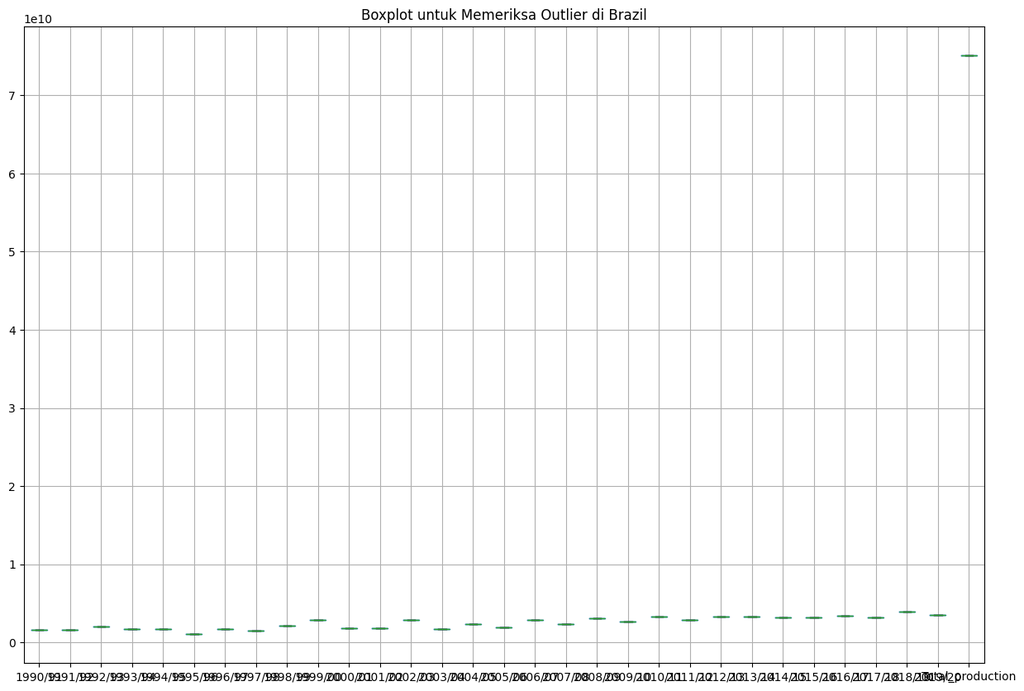

```python
import pandas as pd
    import matplotlib.pyplot as plt

    # Membaca dataset
    url = 'https://raw.githubusercontent.com/Auliyaaas/Proyek-Sains-Data/main/PSD/CoffeeProduction/Coffee_production.csv'
    df = pd.read_csv(url)

    # Memeriksa kolom yang tersedia dalam dataset
    print(df.columns)

    # Pastikan nama kolom negara sesuai, misalnya 'Country'
    # Memfilter data hanya untuk negara Brazil
    brazil_data = df[df['Country'] == 'Brazil']

    # Menampilkan beberapa baris pertama data Brazil
    print(brazil_data.head())

    # Memilih kolom numerik untuk analisis
    numeric_columns = brazil_data.select_dtypes(include=['float64', 'int64']).columns
    print(f"Kolom numerik: {numeric_columns}")

    # Memeriksa outlier menggunakan metode IQR untuk setiap kolom numerik
    for column in numeric_columns:
        Q1 = brazil_data[column].quantile(0.25)  # Kuartil pertama
        Q3 = brazil_data[column].quantile(0.75)  # Kuartil ketiga
        IQR = Q3 - Q1  # Interquartile Range
        lower_bound = Q1 - 1.5 * IQR
        upper_bound = Q3 + 1.5 * IQR

        outliers = brazil_data[(brazil_data[column] < lower_bound) | (brazil_data[column] > upper_bound)]
        print(f"\nKolom: {column}")
        print(f"Jumlah outlier di Brazil: {len(outliers)}")
        if not outliers.empty:
            print(outliers[[column]])

    # Visualisasi menggunakan boxplot
    plt.figure(figsize=(15, 10))
    brazil_data[numeric_columns].boxplot()
    plt.title("Boxplot untuk Memeriksa Outlier di Brazil")
    plt.show()
```

Pada dataset terkhusus untuk negara brazil ini tidak ditemukan outlier. Terlihat dari grafik yang tidak terlihat adanya grafik yang melenceng.

# Prepocessing

Preprocessing adalah tahapan dalam proses analisi data yang melibatkan persiapan dan pembersihan data mentah agar siap untuk dianalisis atau dimasukkan ke dalam model. Langkah-langkah ini penting untuk memastikan bahwa data berada dalam format yang sesuai dan bebas dari kesalahan yang bisa mempengaruhi hasil analisis.

## Data Testing dan Data Training

```python
import pandas as pd
    from sklearn.model_selection import train_test_split

    # Membaca dataset
    url = 'https://raw.githubusercontent.com/Auliyaaas/Proyek-Sains-Data/main/PSD/CoffeeProduction/Coffee_production.csv'
    df = pd.read_csv(url)

    # Memfilter data untuk negara Brazil
    brazil_data = df[df['Country'] == 'Brazil']

    # Mengubah data tahun menjadi baris menggunakan melt
    brazil_data_melted = brazil_data.melt(
        id_vars=['Country', 'Coffee type'],
        var_name='Year',
        value_name='Production'
    )

    # Memeriksa beberapa baris pertama dari data yang sudah dimelt
    print("Data setelah transformasi (melt):")
    print(brazil_data_melted.head())

    # Memilih fitur (X) dan target (y)
    X = brazil_data_melted[['Year']]  # Fitur input
    y = brazil_data_melted['Production']  # Target output

    # Mengatasi nilai NaN pada kolom 'Year'
    # Jika ada NaN di kolom 'Year', kita bisa menghapus atau mengisi NaN
    X = X.dropna(subset=['Year'])  # Menghapus baris dengan NaN di kolom 'Year'

    # Pastikan kolom 'Year' sudah dalam format string sebelum ekstraksi
    X['Year'] = X['Year'].str.extract('(\d{4})').astype(float)  # Menjadi numerik dengan tipe float

    # Membagi dataset menjadi data training dan testing
    X_train, X_test, y_train, y_test = train_test_split(X, y, test_size=0.2, random_state=42)

    # Menampilkan ukuran data setelah pembagian
    print("\nUkuran data training:")
    print(f"X_train: {X_train.shape}, y_train: {y_train.shape}")
    print("\nUkuran data testing:")
    print(f"X_test: {X_test.shape}, y_test: {y_test.shape}")
```

```
Data setelah transformasi (melt):
      Country      Coffee type     Year    Production
    0  Brazil  Arabica/Robusta  1990/91  1.637160e+09
    1  Brazil  Arabica/Robusta  1991/92  1.637580e+09
    2  Brazil  Arabica/Robusta  1992/93  2.076180e+09
    3  Brazil  Arabica/Robusta  1993/94  1.690020e+09
    4  Brazil  Arabica/Robusta  1994/95  1.691520e+09

    Ukuran data training:
    X_train: (24, 1), y_train: (24,)

    Ukuran data testing:
    X_test: (7, 1), y_test: (7,)
```

Hasil dari pembagian dataset menjadi data training dan testing menggunakan fungsi train_test_split() dari scikit-learn. Penjelasan untuk setiap bagian output adalah sebagai berikut:

### Ukuran data Testing(20%)

- X_test: (7, 1) menunjukkan bahwa ada 7 baris data dalam dataset testing, dan hanya ada 1 fitur (kolom 'Year') yang digunakan. Model akan menguji prediksi pada 7 data yang berisi tahun (fitur) dari data testing.
- y_test: (7,) menunjukkan bahwa ada 7 nilai target yang sesuai dengan data testing, yaitu kolom 'Production'. Nilai ini akan digunakan untuk mengevaluasi kinerja model setelah dilatih dengan data training.

# Pemodelan

Pemodelan dalam penambangan data adalah alat untuk mengubah data mentah menjadi wawasan berharga yang dapat digunakan untuk mendukung keputusan strategis dalam berbagai bidang. Dalam pengerjaan ini digunakan beberapa pemodelan yaitu sebagai berikut:

**Linear Regression**

Linear Regression adalah metode regresi sederhana yang memodelkan hubungan linier antara variabel input (X) dan output (Y). Model ini mencoba mencari garis lurus terbaik (best-fit line) yang meminimalkan selisih kuadrat (least squares) antara nilai prediksi dan nilai aktual.

**Support Vector Regression (SVR)**

Model ini mencoba menemukan garis regresi dalam margin tertentu (𝜖) sehingga kesalahan prediksi yang kecil tidak diperhatikan. SVR dapat menggunakan kernel seperti linear, polynomial, dan RBF untuk menangani data non-linier.

**Decision Tree Regression**

Decision Tree membagi data secara rekursif berdasarkan fitur untuk membuat model pohon keputusan. Model ini mempartisi data ke dalam beberapa "daun," di mana setiap daun berisi prediksi nilai rata-rata dari data di dalamnya.

- Algoritma Dasar:
1. Memilih fitur terbaik untuk membagi data (berdasarkan pengurangan impurity seperti MSE atau MAE).
2. Membagi data hingga memenuhi kriteria stopping (misalnya, kedalaman pohon maksimum atau jumlah data minimum di daun).

**Random Forest Regression**

Random Forest adalah metode ensemble yang menggunakan banyak Decision Trees. Prediksi akhir adalah rata-rata prediksi dari semua pohon di ensemble. Model ini mengurangi masalah overfitting yang sering terjadi pada Decision Tree dengan menggabungkan hasil dari beberapa pohon.

```python
import pandas as pd
    import numpy as np
    from sklearn.linear_model import LinearRegression
    from sklearn.tree import DecisionTreeRegressor
    from sklearn.svm import SVR
    from sklearn.ensemble import RandomForestRegressor
    from sklearn.preprocessing import StandardScaler
    from sklearn.metrics import mean_squared_error, mean_absolute_error, r2_score
    import matplotlib.pyplot as plt
```

```python
# Memuat dataset
    file_path = 'https://raw.githubusercontent.com/Auliyaaas/Proyek-Sains-Data/main/PSD/CoffeeProduction/Coffee_production.csv'
    data = pd.read_csv(file_path)
```

```python
brazil_data = data[data['Country'] == 'Brazil']
```

```python
# Pilih kolom tahun sebagai fitur
    year_columns = [col for col in brazil_data.columns if '1990/91' <= col <= '2021/22']
    X = np.arange(len(year_columns)).reshape(-1, 1)  # Buat array urutan tahun sebagai fitur
    y = brazil_data[year_columns].values.flatten()  # Data produksi sebagai target
```

```python
# Normalisasi data target
    scaler = StandardScaler()
    y = scaler.fit_transform(y.reshape(-1, 1)).flatten()
```

```python
# Fungsi untuk evaluasi model
    def evaluate_model(model, model_name):
        # Melatih model
        model.fit(X, y)

        # Prediksi untuk data pelatihan
        y_train_pred = model.predict(X)

        # Ubah kembali ke skala aslinya
        y_train_pred = scaler.inverse_transform(y_train_pred.reshape(-1, 1)).flatten()
        y_actual = scaler.inverse_transform(y.reshape(-1, 1)).flatten()

        # Menghitung metrik evaluasi
        mse = mean_squared_error(y_actual, y_train_pred)
        rmse = np.sqrt(mse)
        mae = mean_absolute_error(y_actual, y_train_pred)
        r2 = r2_score(y_actual, y_train_pred)

        print(f"\nEvaluasi Model {model_name}:")
        print(f"MSE: {mse:.2f}")
        print(f"RMSE: {rmse:.2f}")
        print(f"MAE: {mae:.2f}")
        print(f"R-squared: {r2:.4f}")

        return rmse, model
```

```python
# Evaluasi Model Support Vector Regressor (SVR)
    rmse_svr, model_svr = evaluate_model(SVR(kernel='rbf'), "Support Vector Regressor (SVR)")
```

```
    Evaluasi Model Support Vector Regressor (SVR):
    MSE: 125189196042294480.00
    RMSE: 353820853.03
    MAE: 264170326.32
    R-squared: 0.7698
```

```python
# Evaluasi Model Random Forest
    rmse_rf, model_rf = evaluate_model(RandomForestRegressor(n_estimators=100, random_state=42), "Random Forest")
```

```
    Evaluasi Model Random Forest:
    MSE: 35452289644020008.00
    RMSE: 188287784.11
    MAE: 156992860.00
    R-squared: 0.9348
```

```python
# Evaluasi Model Decision Tree
    rmse_dt, model_dt = evaluate_model(DecisionTreeRegressor(), "Decision Tree")
```

```
    Evaluasi Model Decision Tree:
    MSE: 0.00
    RMSE: 0.00
    MAE: 0.00
    R-squared: 1.0000
```

```python
# Evaluasi Model Linear Regression
    rmse_lr, model_lr = evaluate_model(LinearRegression(), "Linear Regression")
```

```
    Evaluasi Model Linear Regression:
    MSE: 126537605409548368.00
    RMSE: 355721246.78
    MAE: 288377969.89
    R-squared: 0.7673
```

Pada setiap model telah mengoutputkan MSE, RMSE, MAE, R-Squared nya masing - masing. langkah selanjutnya adalah menentukan model dengan RMSE terendah.

```python
# Menentukan model dengan RMSE terendah
    best_rmse = min(rmse_dt, rmse_svr, rmse_rf, rmse_lr)
    if best_rmse == rmse_dt:
        best_model = model_dt
    elif best_rmse == rmse_svr:
        best_model = model_svr
    elif best_rmse == rmse_rf:
        best_model = model_rf
    else:
        best_model = model_lr
```

```python
# Menampilkan model terbaik berdasarkan RMSE
    print(f"\nModel terbaik berdasarkan RMSE: {best_model.__class__.__name__} dengan RMSE: {best_rmse:.2f}")
```

```
    Model terbaik berdasarkan RMSE: DecisionTreeRegressor dengan RMSE: 0.00
```

Didapatkan model dengan nilai RMSE terndah adalah dengan menggunakan model Decision Tree Regressor. Dengan nilai **RMSE : 0.00**

Nilai aktual dan nilai prediksi didapat dari proses evaluasi model machine learning:

1. Nilai Aktual, Nilai ini berasal dari dataset asli. Misalnya, jika Anda memiliki data produksi kopi per tahun, nilai produksi sebenarnya dari dataset dianggap sebagai nilai aktual.
2. Nilai Prediksi, Nilai ini berasal dari model yang telah dilatih menggunakan data training. Model menghasilkan nilai prediksi berdasarkan input (fitur) pada data testing.

```python
import pandas as pd
    import numpy as np
    from sklearn.model_selection import train_test_split
    from sklearn.tree import DecisionTreeRegressor

    # Data produksi kopi untuk negara Brazil
    data = {
        'Year': [
            1990, 1991, 1992, 1993, 1994, 1995, 1996, 1997, 1998, 1999,
            2000, 2001, 2002, 2003, 2004, 2005, 2006, 2007, 2008, 2009,
            2010, 2011, 2012, 2013, 2014, 2015, 2016, 2017, 2018, 2019
        ],
        'Production': [
            1637160000, 1637580000, 2076180000, 1690020000, 1691520000,
            1083600000, 1751820000, 1568880000, 2205660000, 2854680000,
            1878600000, 1881900000, 2901120000, 1732380000, 2356860000,
            1975980000, 2905920000, 2334660000, 3089460000, 2638620000,
            3325680000, 2915520000, 3325080000, 3281340000, 3198300000,
            3172260000, 3407280000, 3164400000, 3907860000, 3492660000
        ]
    }

    # Membuat DataFrame
    df = pd.DataFrame(data)

    # Memisahkan fitur (X) dan target (y)
    X = df[['Year']]  # Fitur: Tahun
    y = df['Production']  # Target: Produksi

    # Membagi data menjadi training dan testing
    X_train, X_test, y_train, y_test = train_test_split(X, y, test_size=0.3, random_state=42)

    # Melatih model Decision Tree Regressor
    model = DecisionTreeRegressor(random_state=42)
    model.fit(X_train, y_train)

    # Mendapatkan nilai prediksi pada data testing
    y_predicted = model.predict(X_test)

    # Menampilkan nilai aktual dan prediksi
    print("Nilai Aktual (y_test):")
    print(y_test.values)

    print("\nNilai Prediksi (y_predicted):")
    print(y_predicted)
```

```
Nilai Aktual (y_test):
    [3164400000 1975980000 3281340000 2334660000 2205660000 2854680000
     3907860000 3198300000 2901120000]

    Nilai Prediksi (y_predicted):
    [3.40728e+09 2.35686e+09 3.32508e+09 2.90592e+09 1.56888e+09 1.87860e+09
     3.49266e+09 3.17226e+09 1.88190e+09]
```

Dari hasil perhitungan nilai aktual dan prediksi dataset tersebut di peroleh

1. Nilai aktual nya adalah **[3164400000, 1975980000, 3281340000, 2334660000, 2205660000, 2854680000, 3907860000, 3198300000, 2901120000]**
2. Nilai Prediksi nya adalah **[3.40728e+09, 2.35686e+09, 3.32508e+09, 2.90592e+09, 1.56888e+09, 1.87860e+09, 3.49266e+09, 3.17226e+09, 1.88190e+09]**

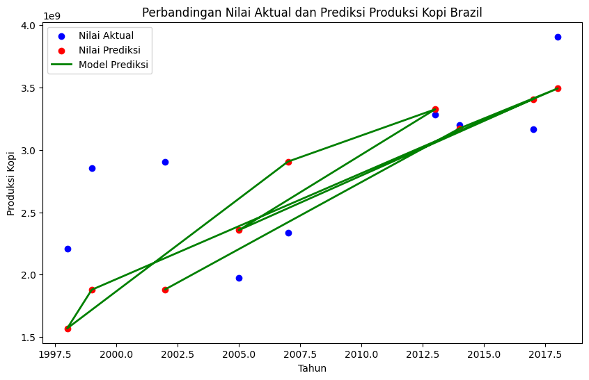

```python
plt.figure(figsize=(10,6))
    plt.scatter(X_test, y_test, color='blue', label='Nilai Aktual')
    plt.scatter(X_test, y_predicted, color='red', label='Nilai Prediksi')
    plt.plot(X_test, y_predicted, color='green', linewidth=2, label='Model Prediksi')

    plt.title('Perbandingan Nilai Aktual dan Prediksi Produksi Kopi Brazil')
    plt.xlabel('Tahun')
    plt.ylabel('Produksi Kopi')
    plt.legend()

    # Menampilkan grafik
    plt.show()
```

## MAPE (Mean Absolute Percentage Error)

MAPE (Mean Absolute Percentage Error) adalah ukuran kesalahan prediksi yang digunakan untuk mengevaluasi seberapa baik suatu model memprediksi nilai target dibandingkan nilai aktual.

```python
import numpy as np

    # Contoh nilai aktual dan prediksi
    y_actual = np.array([3164400000, 1975980000, 3281340000, 2334660000, 2205660000, 2854680000,
     3907860000, 3198300000, 2901120000])
    y_predicted = np.array([3.40728e+09, 2.35686e+09, 3.32508e+09, 2.90592e+09, 1.56888e+09, 1.87860e+09,
     3.49266e+09, 3.17226e+09, 1.88190e+09])

    # Fungsi untuk menghitung MAPE
    def mean_absolute_percentage_error(y_actual, y_predicted):
        # Pastikan tidak ada pembagian dengan nol
        non_zero_mask = y_actual != 0
        y_actual = y_actual[non_zero_mask]
        y_predicted = y_predicted[non_zero_mask]

        # Rumus MAPE
        mape = np.mean(np.abs((y_actual - y_predicted) / y_actual)) * 100
        return mape

    # Menghitung MAPE
    mape = mean_absolute_percentage_error(y_actual, y_predicted)
    print(f"MAPE: {mape:.2f}%")
```

```
MAPE: 18.04%
```

Diperoleh dari perhitungan MAPE yang dihitung dari nilai Aktual dan nilai prediksinya yaitu **18.04%**

```python
# Prediksi untuk tahun berikutnya menggunakan model terbaik
    next_year = np.array([[len(year_columns)]])  # Tahun berikutnya dalam urutan waktu
    y_pred_next_year = best_model.predict(next_year)

    # Ubah kembali ke skala aslinya
    y_pred_next_year = scaler.inverse_transform(y_pred_next_year.reshape(-1, 1)).flatten()

    # Menampilkan prediksi produksi kopi untuk tahun berikutnya
    print(f"Prediksi Produksi Kopi di Brazil untuk tahun berikutnya: {y_pred_next_year[0]:.2f}")
```

```
Prediksi Produksi Kopi di Brazil untuk tahun berikutnya: 3492660000.00
```

Dari program diatas, dapat disimpulkan bahwa hasil prediksi jumlah produksi kopi ditahun berikutnya untuk negara Brazil adalah **3492660000.00**

```python
# Pastikan kolom tahun diubah menjadi angka valid (mengambil bagian pertama dari format seperti '1990/91')
    year_columns = [int(year.split('/')[0]) if '/' in year else int(year) for year in year_columns]

    # Meminta input tahun dari pengguna
    input_year = int(input("Masukkan tahun untuk memprediksi produksi kopi: "))

    # Pastikan input tahun valid (lebih besar dari tahun terakhir dalam dataset)
    if input_year <= max(year_columns):
        print("Tahun harus lebih besar dari tahun terakhir dalam dataset.")
    else:
        # Mengubah tahun menjadi fitur numerik berdasarkan urutan waktu
        next_year = np.array([[input_year - min(year_columns)]])  # Perbedaan dengan tahun awal sebagai fitur

        # Prediksi produksi kopi menggunakan model terbaik
        y_pred_next_year = best_model.predict(next_year)

        # Ubah kembali prediksi ke skala aslinya
        y_pred_next_year = scaler.inverse_transform(y_pred_next_year.reshape(-1, 1)).flatten()

        # Menampilkan hasil prediksi
        print(f"Prediksi Produksi Kopi di Brazil untuk tahun {input_year}: {y_pred_next_year[0]:.2f}")
```

```
Masukkan tahun untuk memprediksi produksi kopi: 2025
    Prediksi Produksi Kopi di Brazil untuk tahun 2025: 3492660000.00
```